# Logistic regression

### The dataset

We begin by reading in the alc data set:

```r
alc <- read.csv("data/alc.csv")
colnames(alc)
```

```
##  [1] "school"     "sex"        "age"        "address"    "famsize"
##  [6] "Pstatus"    "Medu"       "Fedu"       "Mjob"       "Fjob"
## [11] "reason"     "nursery"    "internet"   "guardian"   "traveltime"
## [16] "studytime"  "failures"   "schoolsup"  "famsup"     "paid"
## [21] "activities" "higher"     "romantic"   "famrel"     "freetime"
## [26] "goout"      "Dalc"       "Walc"       "health"     "absences"
## [31] "G1"         "G2"         "G3"         "alc_use"    "high_use"
```

This is a joined data set, combining student data from two Portuguese schools. The data set describes school performance in mathematics and Portuguese language, but it also contains information regarding student background, activities and social factors. Of particular interest to us are the alc_use and high_use variables, which describe student alcohol consumption.

In this analysis, we study the relationships between alcohol consumption and the following four variables: G3, famrel, internet and studytime. G3 is the final year school grade, famrel describes family relationships, internet stands for internet access at home, and studytime is the student’s weekly study time.

Before looking at the data, we would expect high alcohol consumption to correlate with lower final year grades, worse family relationships, no internet access at home, and less weekly study time.

We will now load in the necessary libraries and then we’ll go through the relationships between the variables one by one.

```r
library(dplyr)
```

```r
library(ggplot2)
library(gridExtra)
```

### Final year grades

We begin with the final year grades, G3. Below, we have plotted the distribution of final year grades and the relationship between the grades and alcohol consumption. We have also listed mean grades for the low/high alcohol consumption groups.

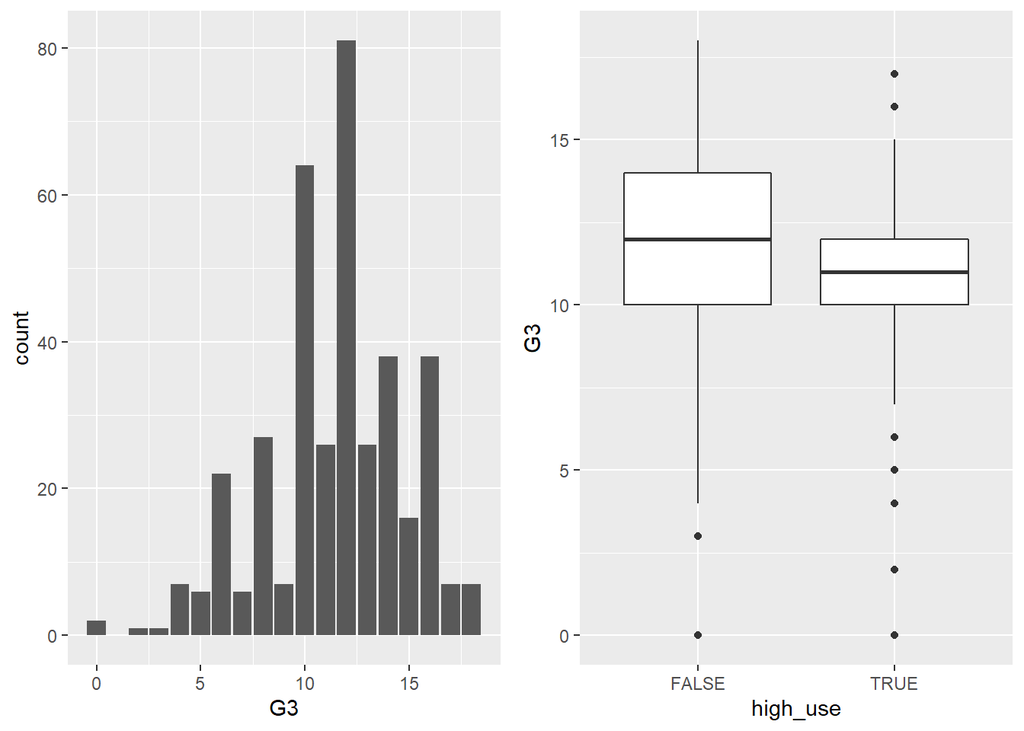

```r
g1 <- ggplot(data = alc, aes(x = G3))
g2 <- ggplot(alc, aes(x = high_use, y = G3))
grid.arrange(g1 + geom_bar(), g2 + geom_boxplot(), nrow=1, ncol=2)
```

```r
alc %>% group_by(high_use) %>% summarise(count = n(), mean_grade = mean(G3))
```

```
## # A tibble: 2 x 3
##   high_use count mean_grade
##   <lgl>    <int>      <dbl>
## 1 FALSE      268       11.7
## 2 TRUE       114       10.8
```

We see that the distribution of grades in the data set leans towards the upper half of the range. We also see that our hypothesis regarding grades appears to be correct: the mean final year grade is about a point lower for the high alcohol consumption group.

### Family relationships

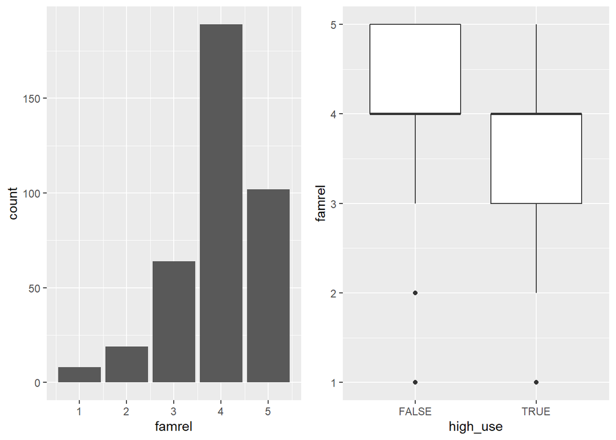

```r
g1 <- ggplot(data = alc, aes(x = famrel))
g2 <- ggplot(alc, aes(x = high_use, y = famrel))
grid.arrange(g1 + geom_bar(), g2 + geom_boxplot(), nrow=1, ncol=2)
```

```r
alc %>% group_by(high_use) %>% summarise(count = n(), mean_rel = mean(famrel))
```

```
## # A tibble: 2 x 3
##   high_use count mean_rel
##   <lgl>    <int>    <dbl>
## 1 FALSE      268     4.00
## 2 TRUE       114     3.78
```

Family relationships in the data set appear to be very good on average, with the distribution leaning heavily towards the top end. Again, the data seems to agree with our hypothesis: students in the high alcohol consumption group have 0.22 points lower family relationship scores on average.

### Internet access

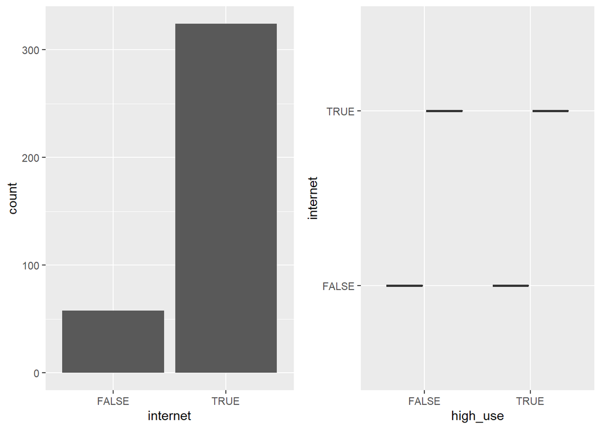

```r
alc$internet <- ifelse(alc$internet == "yes", TRUE, FALSE)
g1 <- ggplot(data = alc, aes(x = internet))
g2 <- ggplot(alc, aes(x = high_use, y = internet))
grid.arrange(g1 + geom_bar(), g2 + geom_boxplot(), nrow=1, ncol=2)
```

```r
alc %>% group_by(high_use) %>% summarise(count = n(), mean_int = mean(internet))
```

```
## # A tibble: 2 x 3
##   high_use count mean_int
##   <lgl>    <int>    <dbl>
## 1 FALSE      268    0.840
## 2 TRUE       114    0.868
```

The vast majority of students have internet access at home. Unlike for the two previous variables, our hypothesis appears to have been incorrect: the average number of students with internet access was higher in the high alcohol consumption group. The statistical significance also appears to be fairly small.

### Study time

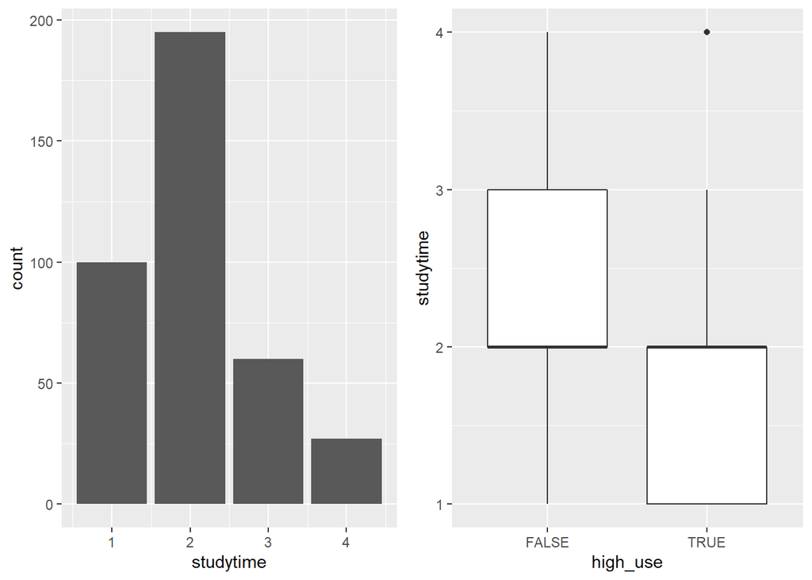

```r
g1 <- ggplot(data = alc, aes(x = studytime))
g2 <- ggplot(alc, aes(x = high_use, y = studytime))
grid.arrange(g1 + geom_bar(), g2 + geom_boxplot(), nrow=1, ncol=2)
```

```r
alc %>% group_by(high_use) %>% summarise(count = n(), mean_time = mean(studytime))
```

```
## # A tibble: 2 x 3
##   high_use count mean_time
##   <lgl>    <int>     <dbl>
## 1 FALSE      268      2.15
## 2 TRUE       114      1.77
```

The weekly study times in the data set lean heavily towards the lower end of the range. We also see that our final hypothesis agrees with the data: the average study time score for the high alcohol consumption group is 0.38 points lower than for the low alcohol consumption group.

### Logistic regression model

```r
m <- glm(high_use ~ G3 + famrel + internet + studytime, data = alc, family = "binomial")
summary(m)
```

```
##
## Call:
## glm(formula = high_use ~ G3 + famrel + internet + studytime,
##     family = "binomial", data = alc)
##
## Deviance Residuals:
##     Min       1Q   Median       3Q      Max
## -1.4304  -0.8505  -0.6894   1.2579   2.1807
##
## Coefficients:
##              Estimate Std. Error z value Pr(>|z|)
## (Intercept)   1.64867    0.70052   2.354 0.018597 *
## G3           -0.06574    0.03555  -1.849 0.064440 .
## famrel       -0.26075    0.12549  -2.078 0.037718 *
## internetTRUE  0.40748    0.33570   1.214 0.224809
## studytime    -0.56043    0.15471  -3.622 0.000292 ***
## ---
## Signif. codes:  0 '***' 0.001 '**' 0.01 '*' 0.05 '.' 0.1 ' ' 1
##
## (Dispersion parameter for binomial family taken to be 1)
##
##     Null deviance: 465.68  on 381  degrees of freedom
## Residual deviance: 439.49  on 377  degrees of freedom
## AIC: 449.49
##
## Number of Fisher Scoring iterations: 4
```

```r
OR <- coef(m) %>% exp
CI <- confint(m) %>% exp
cbind(OR, CI)
```

```
##                     OR     2.5 %     97.5 %
## (Intercept)  5.2000754 1.3260620 20.8757272
## G3           0.9363736 0.8727652  1.0036694
## famrel       0.7704725 0.6017345  0.9858459
## internetTRUE 1.5030276 0.7942183  2.9834260
## studytime    0.5709640 0.4176457  0.7670617
```

Above, we have listed a summary of our logistic regression model, the coefficients of the model as odd ratios and their confidence intervals.

From the p-values of the summary we can see that out of all the variables we considered, study time has by far the most significant statistical relationship with alcohol consumption. Family relationships also have some statistical significance, final year grades have very little, and internet access has none. The estimated coefficients are negative for the three variables of significance, which tells us that when study scores, family relations or study time goes down, the prediction for high alcohol consumption goes up.

The logistic regression model agrees with our hypothesis for the variables studytime, famrel and G3, but disagrees with our hypothesis for the variable internet, which turned out to be statistically insignificant.

### Predictions

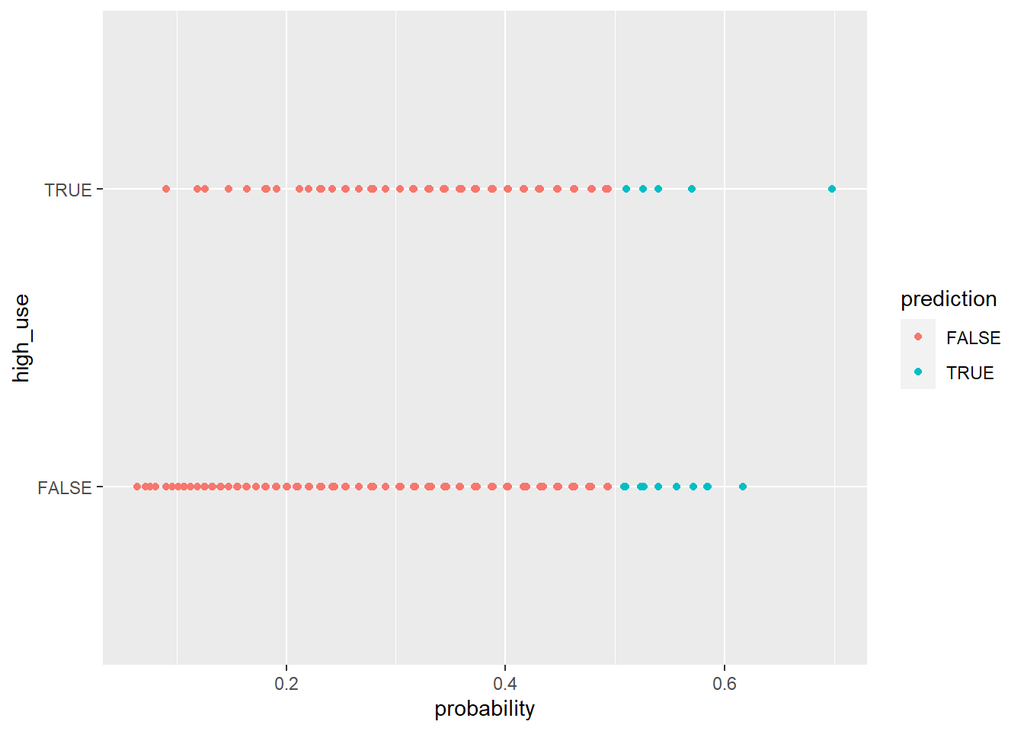

```r
m <- glm(high_use ~ studytime + famrel + G3, data = alc, family = "binomial")
probabilities <- predict(m, type = "response")
alc <- mutate(alc, probability = probabilities)
alc <- mutate(alc, prediction = probability > 0.5)
g <- ggplot(alc, aes(x = probability, y = high_use, col = prediction))
g + geom_point()
```

```r
table(high_use = alc$high_use, prediction = alc$prediction)
```

```
##         prediction
## high_use FALSE TRUE
##    FALSE   255   13
##    TRUE    107    7
```

We see that our model does a decent job of predicting when there is no high alcohol consumption (with only 13 false positives), but it has issues recognizing when there is (it missed 107 cases). We can also consider the training error:

```r
loss_func <- function(class, prob) {
  n_wrong <- abs(class - prob) > 0.5
  mean(n_wrong)
}
loss_func(class = alc$high_use, prob = alc$probability)
```

```
## [1] 0.3141361
```

```r
loss_func(class = alc$high_use, prob = 0)
```

```
## [1] 0.2984293
```

```r
loss_func(class = alc$high_use, prob = 1)
```

```
## [1] 0.7015707
```

Above, we have computed the total proportion of inaccurately classified observations for our model, as well as the corresponding proportions for two simple guesses: always assuming that there is no high alcohol consumption, and always assuming that there is. In this case, the simple guessing strategy that there is no high alcohol consumption has slightly less error (0.2984) than our model (0.3141). The other guessing strategy of always assuming high alcohol consumption yields much worse results at 0.7015.

### Bonus: Cross-validation

```r
library(boot)
cv <- cv.glm(data = alc, cost = loss_func, glmfit = m, K = 10)
cv$delta[1]
```

```
## [1] 0.3167539
```